# Visualizing health data in R and RStudio

Corinne Riddell (Instructor: Alan Hubbard)

August 28, 2023

# Learning objectives for today

1. To put to use the `dplyr` commands from last lecture
2. To make beautiful plots using the `ggplot2` package

# Readings

- Online resource: [Creating a `ggplot`](https://r4ds.had.co.nz/data-visualisation.html)(See sections 3.2.2-3.2.3)

# Life expectancy in the United States by race and gender, 1969-2013

These data are partial results from a study that I did on the difference in life expectancy between Black and White men and women in the United States over time.

A subset of the results have been stored in the datahub folder for today’s lecture as a comma separated value (CSV) file.

Do you remember which function to use to import CSV data into R?

# `readr`’s `read_csv()` to import these data

```r
library(readr)
le_data <- read_csv("./data/Life-expectancy-by-state-long.csv")
```

# Four functions to get to know your dataset

Function 1

```r
head(le_data)
```

```
## # A tibble: 6 × 8
##   state   stabbrs  year sex    Census_Region Census_Division       LE race
##   <chr>   <chr>   <dbl> <chr>  <chr>         <chr>              <dbl> <chr>
## 1 Alabama AL       1969 Female South         East South Central  75.8 white
## 2 Alabama AL       1969 Male   South         East South Central  66.6 white
## 3 Alabama AL       1970 Female South         East South Central  75.9 white
## 4 Alabama AL       1970 Male   South         East South Central  66.7 white
## 5 Alabama AL       1971 Female South         East South Central  76.2 white
## 6 Alabama AL       1971 Male   South         East South Central  66.9 white
```

# Four functions to get to know your dataset

Function 2

```r
dim(le_data)
```

```
## [1] 7200    8
```

# Four functions to get to know your dataset

Function 3

```r
names(le_data)
```

```
## [1] "state"           "stabbrs"         "year"            "sex"
## [5] "Census_Region"   "Census_Division" "LE"              "race"
```

# Four functions to get to know your dataset

Function 4

```r
str(le_data)
```

```
## spc_tbl_ [7,200 × 8] (S3: spec_tbl_df/tbl_df/tbl/data.frame)
##  $ state          : chr [1:7200] "Alabama" "Alabama" "Alabama" "Alabama" ...
##  $ stabbrs        : chr [1:7200] "AL" "AL" "AL" "AL" ...
##  $ year           : num [1:7200] 1969 1969 1970 1970 1971 ...
##  $ sex            : chr [1:7200] "Female" "Male" "Female" "Male" ...
##  $ Census_Region  : chr [1:7200] "South" "South" "South" "South" ...
##  $ Census_Division: chr [1:7200] "East South Central" "East South Central" "East South Central" "East South Central" ...
##  $ LE             : num [1:7200] 75.8 66.6 75.9 66.7 76.2 ...
##  $ race           : chr [1:7200] "white" "white" "white" "white" ...
##  - attr(*, "spec")=
##   .. cols(
##   ..   state = col_character(),
##   ..   stabbrs = col_character(),
##   ..   year = col_double(),
##   ..   sex = col_character(),
##   ..   Census_Region = col_character(),
##   ..   Census_Division = col_character(),
##   ..   LE = col_double(),
##   ..   race = col_character()
##   .. )
##  - attr(*, "problems")=<externalptr>
```

# A new useful function: View()

```r
View(le_data)
```

`View()` opens the data viewer pane in RStudio. It does not print anything in the data console.

# Life expectancy for White men in California

Make a scatter plot of the life expectancy for White men in California over time.

Which function from last lecture do we need?

- `mutate()`, `select()`, `filter()`, `rename()`, or `arrange()`?

# `dplyr`’s `filter()` to select a subset of rows

```r
library(dplyr)
wm_cali <- le_data %>% filter(state == "California",
                              sex == "Male",
                              race == "white")

#this is equivalent:
wm_cali <- le_data %>% filter(state == "California" & sex == "Male" & race == "white")
```

# First step to building a `ggplot()`: set up the canvas

- The second line of code below specifies the `data` set and what goes on the `x` and `y` axes

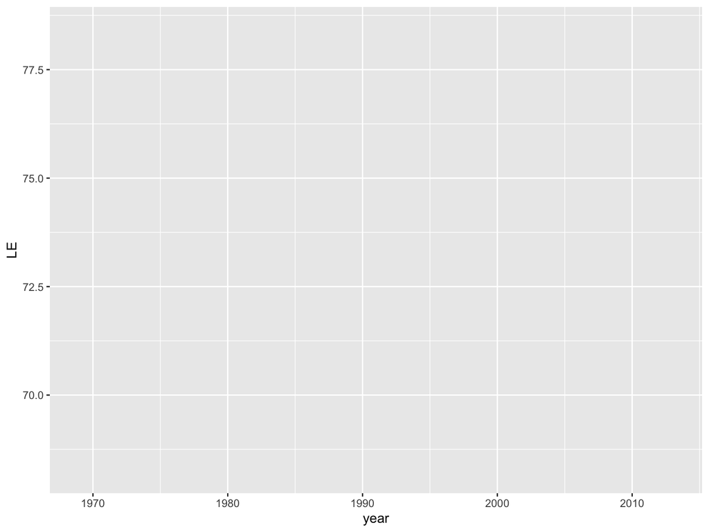

```r
library(ggplot2)
ggplot(data = wm_cali, aes(x = year, y = LE))
```

# Second step to building a `ggplot()`: tell `ggplot` how to plot the data

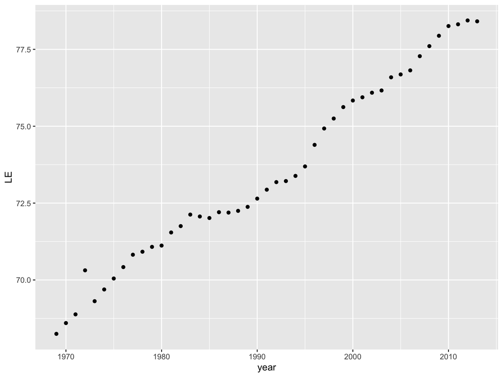

```r
ggplot(data = wm_cali, aes(x = year, y = LE)) + geom_point()
```

- `geom_point()` tells ggplot to use points to plot these data

# `labs()` to add a title, a caption, and modify x and y axes titles

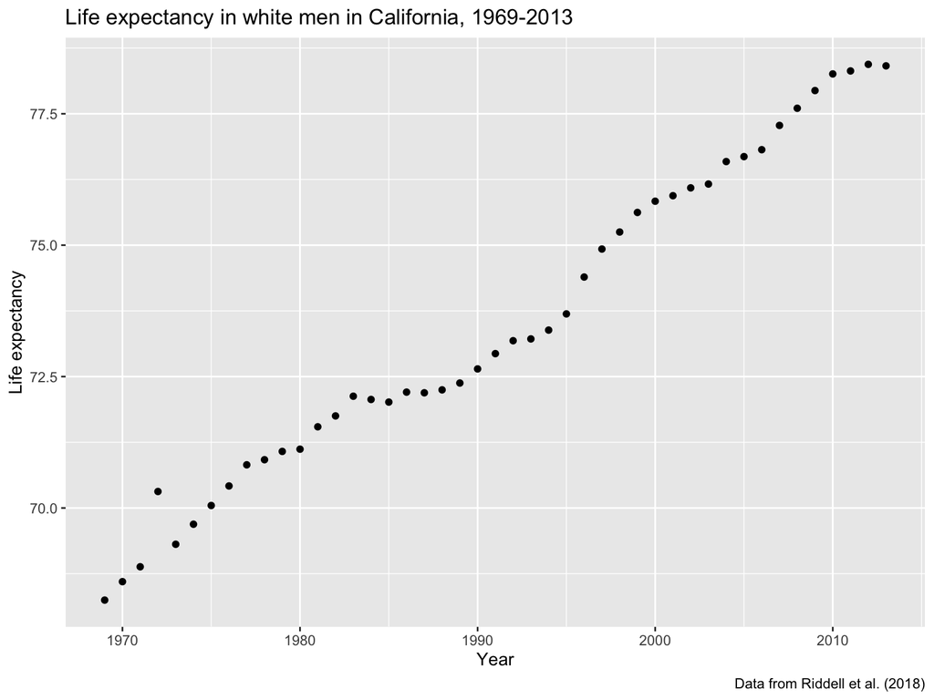

```r
ggplot(data = wm_cali, aes(x = year, y = LE)) + geom_point() +
  labs(title = "Life expectancy in white men in California, 1969-2013",
       y = "Life expectancy",
       x = "Year",
       caption = "Data from Riddell et al. (2018)")
```

# `col` controls the color of geom_point()

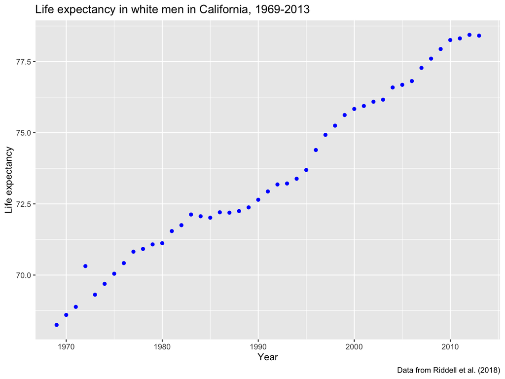

```r
ggplot(data = wm_cali, aes(x = year, y = LE)) + geom_point(col = "blue") +
  labs(title = "Life expectancy in white men in California, 1969-2013",
       y = "Life expectancy",
       x = "Year",
       caption = "Data from Riddell et al. (2018)")
```

# `size` controls the size of geom_point()

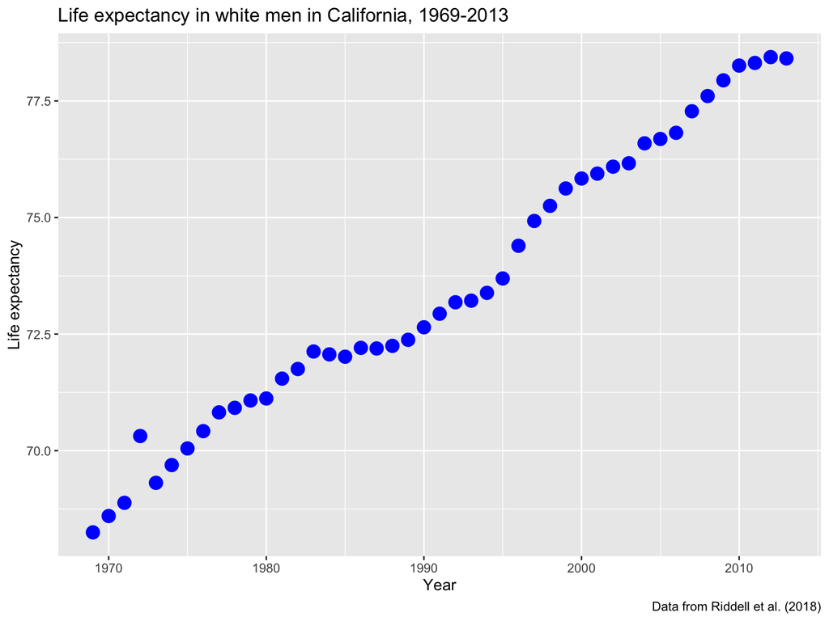

```r
ggplot(data = wm_cali, aes(x = year, y = LE)) + geom_point(col = "blue", size = 4) +
  labs(title = "Life expectancy in white men in California, 1969-2013",
       y = "Life expectancy",
       x = "Year",
       caption = "Data from Riddell et al. (2018)")
```

# Line plot rather than scatter plot

What if we wanted to make these data into a line plot instead. What part of the code should change?

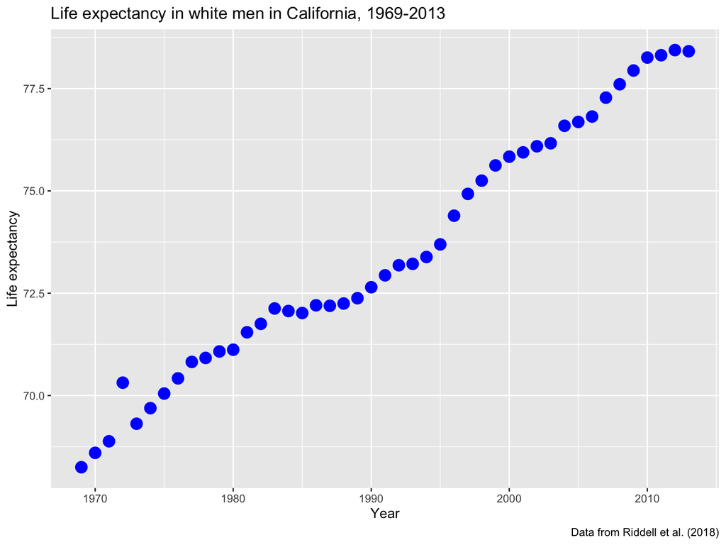

```r
ggplot(data = wm_cali, aes(x = year, y = LE)) +
  geom_point(col = "blue", size = 4) +
  labs(title = "Life expectancy in white men in California, 1969-2013",
       y = "Life expectancy",
       x = "Year",
       caption = "Data from Riddell et al. (2018)")
```

# `geom_line()` to make a line plot

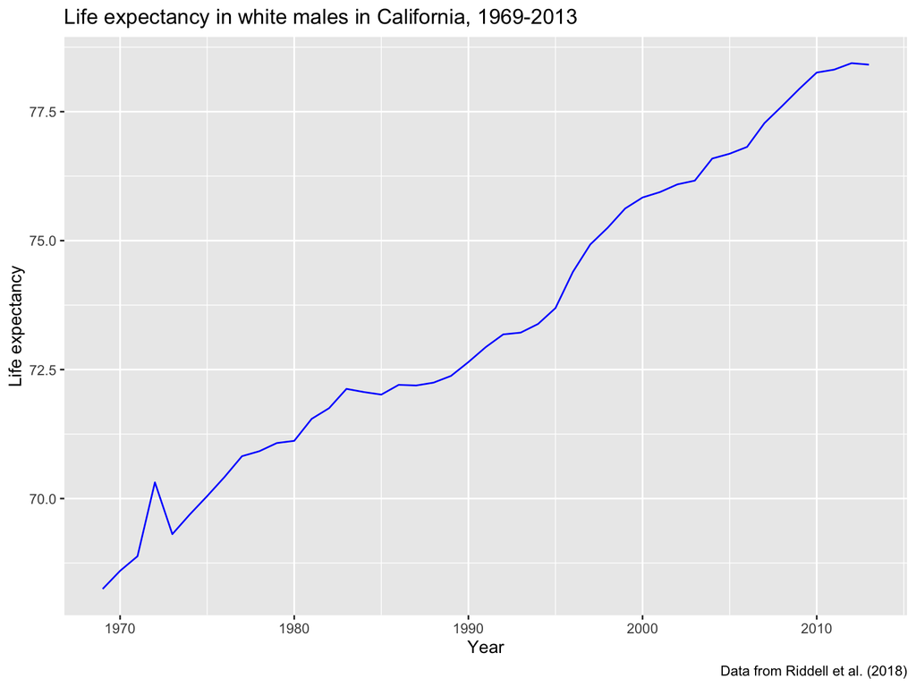

```r
ggplot(data = wm_cali, aes(x = year, y = LE)) + geom_line(col = "blue") +
  labs(title = "Life expectancy in white males in California, 1969-2013",
       y = "Life expectancy",
       x = "Year",
       caption = "Data from Riddell et al. (2018)")
```

# Life expectancy for White and Black men in California

What do we need to change to make a separate line for both Black and White men?

# First, update the `filter()`

```r
wbm_cali <- le_data %>% filter(state == "California",
                               sex == "Male")
```

# Look at the previous code and output first

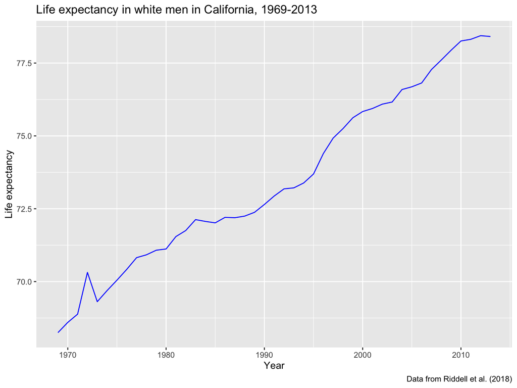

```r
ggplot(data = wm_cali, aes(x = year, y = LE)) + geom_line(col = "blue") +
  labs(title = "Life expectancy in white men in California, 1969-2013",
       y = "Life expectancy",
       x = "Year",
       caption = "Data from Riddell et al. (2018)")
```

# And change it to **link** color to race

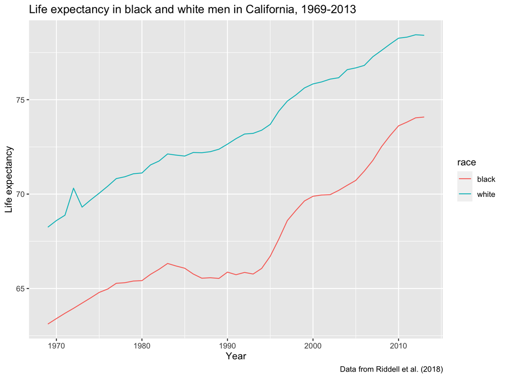

```r
ggplot(data = wbm_cali, aes(x = year, y = LE)) + geom_line(aes(col = race)) +
  labs(title = "Life expectancy in black and white men in California, 1969-2013",
       y = "Life expectancy",
       x = "Year",
       caption = "Data from Riddell et al. (2018)")
```

# Always use the aes() function to link a plot feature to a variable in your data frame

The operative word is *link*. Whenever you want to link something about how the plot looks to a variable in the data frame, you need to *link* these items inside the `aes()` function:

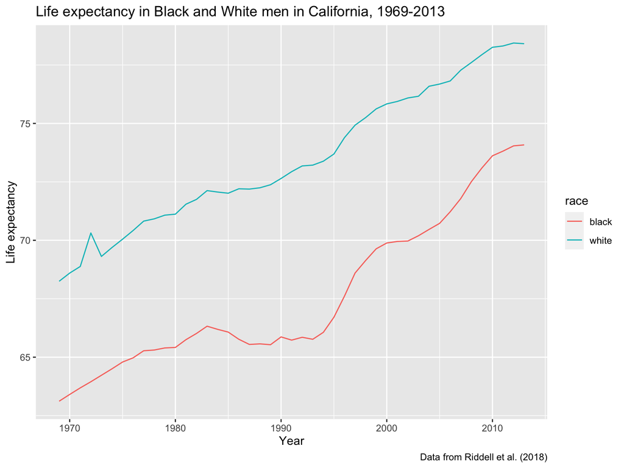

```r
ggplot(data = wbm_cali, aes(x = year, y = LE)) + geom_line(aes(col = race)) +
  labs(title = "Life expectancy in Black and White men in California, 1969-2013",
       y = "Life expectancy",
       x = "Year",
       caption = "Data from Riddell et al. (2018)")
```

# The `aes()` function

- What else was added to the plot when you used the `aes()` function?

# The `aes()` function

- What else was added to the plot when you used the `aes()` function?
  - A legend was added showing the link between the line color and the data frame’s race variable

# What if we also wanted to look at women?

# What if we also wanted to look at women?

```r
cali_data <- le_data %>% filter(state == "California")
```

# What is wrong with this plot?

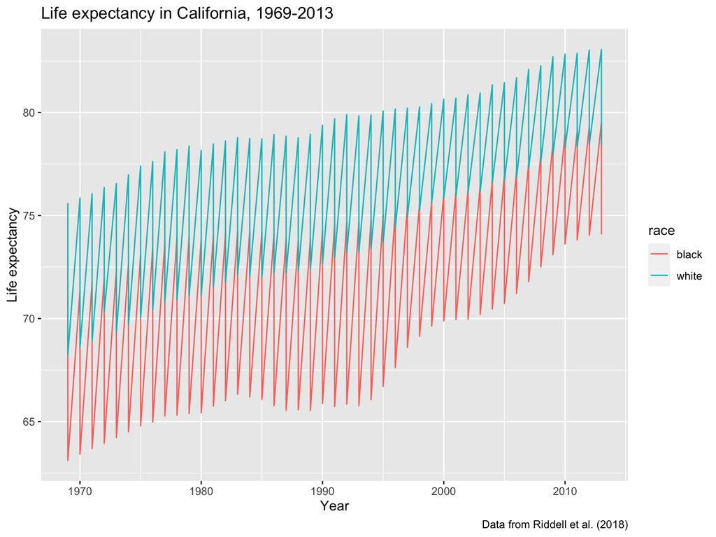

```r
ggplot(data = cali_data, aes(x = year, y = LE)) + geom_line(aes(col = race)) +
  labs(title = "Life expectancy in California, 1969-2013",
       y = "Life expectancy",
       x = "Year",
       caption = "Data from Riddell et al. (2018)")
```

# Use `lty()` to **link** line type to sex

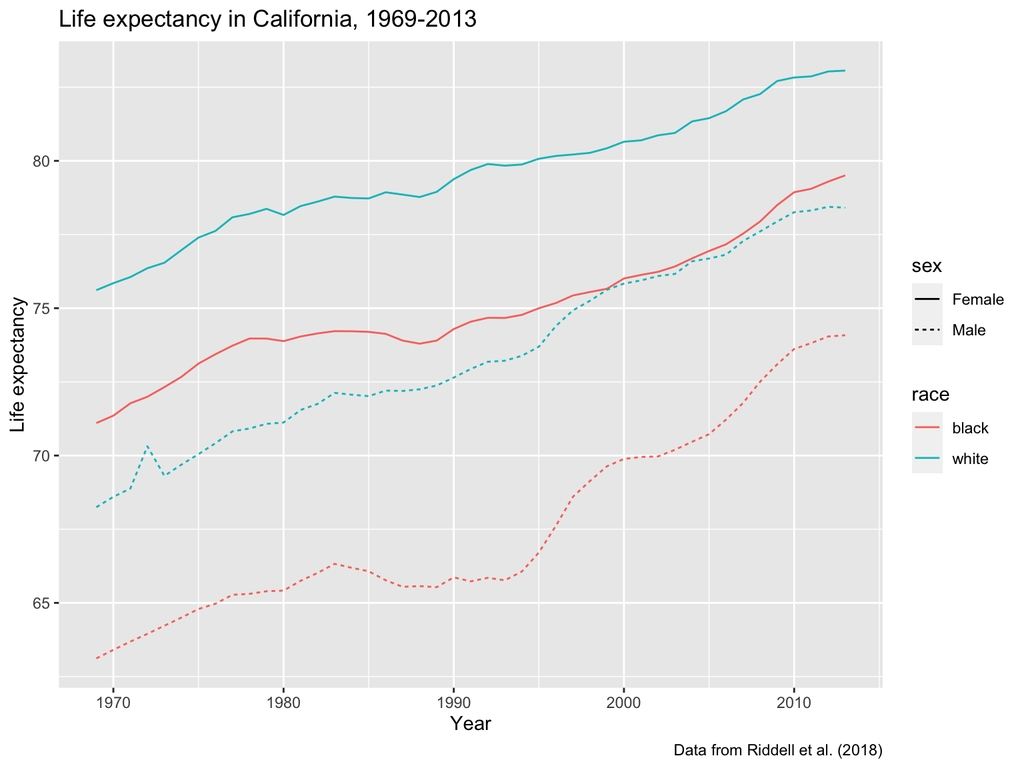

```r
ggplot(data = cali_data, aes(x = year, y = LE)) + geom_line(aes(col = race, lty = sex)) +
  labs(title = "Life expectancy in California, 1969-2013",
       y = "Life expectancy",
       x = "Year",
       caption = "Data from Riddell et al. (2018)")
```

# Use `facet_wrap()` to make separate plots for a specified variable

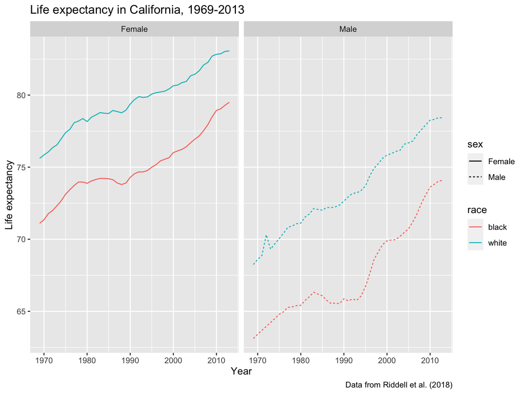

```r
ggplot(data = cali_data, aes(x = year, y = LE)) +
  geom_line(aes(col = race, lty = sex)) +
  labs(title = "Life expectancy in California, 1969-2013",
       y = "Life expectancy",
       x = "Year",
       caption = "Data from Riddell et al. (2018)") +
  facet_wrap(~ sex)
```

# Compare two states

How do we update the `filter` to include data from California and New York?

# Compare two states

```r
updated_data <- le_data %>% filter(state %in% c("California", "New York"))
```

# Let’s write the code together

```r
#to fill in during class
```

# Let’s write the code together

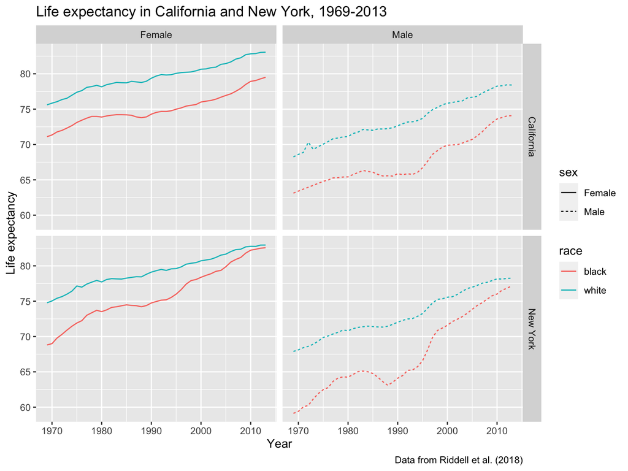

```r
ggplot(data = updated_data, aes(x = year, y = LE)) +
  geom_line(aes(col = race, lty = sex)) +
  labs(title = "Life expectancy in California and New York, 1969-2013",
       y = "Life expectancy",
       x = "Year",
       caption = "Data from Riddell et al. (2018)") +
  facet_grid(state ~ sex)
```

# Check your understanding!

# So far

- `geom_point()` to make scatter plots
- `geom_line()` to make line plots
- `col = "blue"`, `size = 2`, `lty = 2`, to change color, size and line type of the `geom`
- `aes(col = race)` to *link* color to race
- `aes(lty = sex)` to *link* line type to sex
- `facet_wrap(~ var1)` to make separate plots for different levels of one variable
- `facet_grid(var1 ~ var2)` to make separate plots for combinations of levels of two variables

# What if we wanted to make a histogram…

…of life expectancy of white males in 2013?

Before you code, try and visualize what the histogram will show

- What is on the x axis? What is on the y axis?

# Update the `filter`

```r
wm_data <- le_data %>% filter(year == 2013, sex == "Male", race == "white")
```

# `geom_histogram()` to make histograms

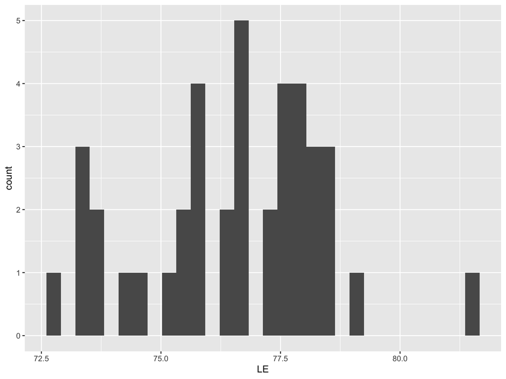

```r
ggplot(dat = wm_data, aes(x = LE)) + geom_histogram()
```

# Use `fill` to change the *fill* of the histogram and `binwidth` to specify the bin’s width

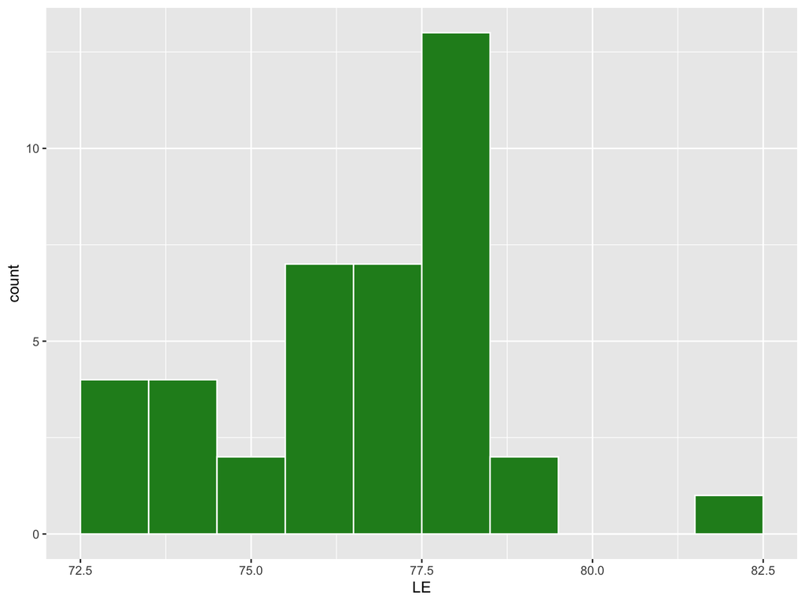

```r
wm_data <- le_data %>% filter(year == 2013, sex == "Male", race == "white")

ggplot(dat = wm_data, aes(x = LE)) +
  geom_histogram(binwidth = 1, col = "white", fill = "forest green")
```

# Apply some of our new skills

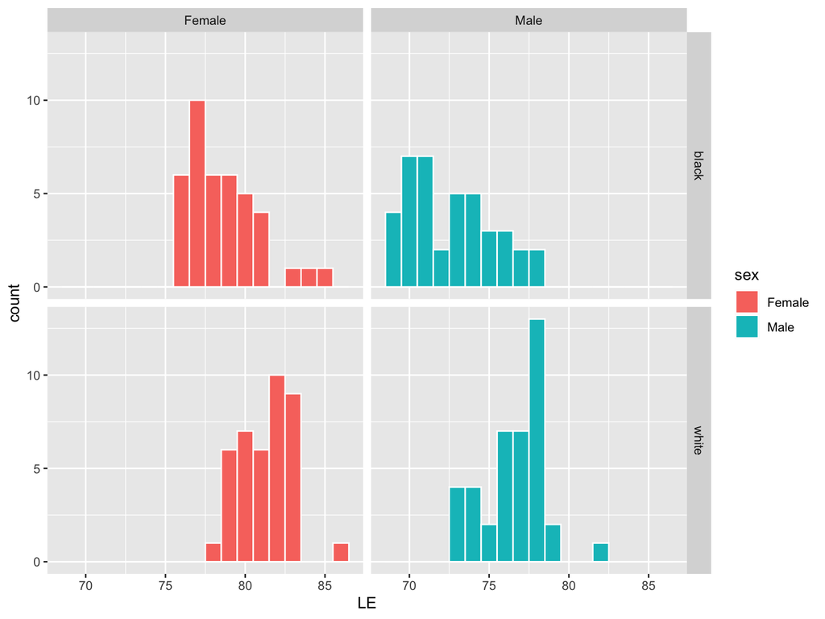

```r
data_2013 <- le_data %>% filter(year == 2013)

ggplot(dat = data_2013, aes(x = LE)) +
  geom_histogram(binwidth = 1, col = "white", aes(fill = sex)) +
  facet_grid(race ~ sex)
```

# Recap: What functions did we learn?

# Recap: What arguments were useful?

2. `ggplot()`
   - `col`
   - `size`
   - `lty`

# A common `dplyr` mistake to avoid!

With dplyr, the pipe operator goes at the end of the line, not the beginning:

Right way:

```r
data_2013 <- le_data %>%
  filter(year == 2013)

#or

data_2013 <- le_data %>% filter(year == 2013)
```

Wrong way:

```r
data_2013 <- le_data
%>% filter(year == 2013)
```

# A common `ggplot` mistake to avoid!

With ggplot2, the “+”” operator goes at the end of the line, not the beginning:

Right way:

```r
ggplot(dat = data_2013, aes(x = LE)) +
  geom_histogram(binwidth = 1, col = "white", aes(fill = sex)) +
  facet_grid(race ~ sex)
```

Wrong way:

```r
ggplot(dat = data_2013, aes(x = LE))
  + geom_histogram(binwidth = 1, col = "white", aes(fill = sex))
  + facet_grid(race ~ sex)
```

# How to get help with code

- Ask questions during discussion, GSI office hours, or on bCourses discussion forum. Use the appropriate thread!
- Develop your online search skills. For example if you have a `ggplot2` question, begin your google search with “r ggplot” and then describe your issues, e.g., “r ggplot how do I make separate lines by a second variable”.
- The most common links that will appear are:
  - https://stackoverflow.com: Crowd-sourced answers that have been upvoted. The top answer is often the best one.
  - https://ggplot2.tidyverse.org/: The official ggplot2 webpage is very helpful.
  - https://community.rstudio.com/: The RStudio community page.
  - https://rpubs.com/: Web pages made by R users that often contain helpful tutorials.

# We only skimmed the surface!

- Here is some extra material for those of you who love data visualization. This material won’t be tested.
  - [RStudio ggplot2 cheatsheet](https://www.rstudio.com/wp-content/uploads/2015/03/ggplot2-cheatsheet.pdf)
  - [Kieran Healy’s data visualization book](https://www.amazon.com/gp/product/0691181624/ref=as_li_tl?ie=UTF8&tag=kieranhealysw-20&camp=1789&creative=9325&linkCode=as2&creativeASIN=0691181624&linkId=16d53b3cc1ec3bc3aac60b27c29b92e8)